# Data analysis based on the sample from DATA2X02 students

## 5.2 Is there any evidence that being a woman increased your frequency of flossing? (Question5.1-My test for independance)

We would like to know if there is enough evidence showing that being a woman increases your floss frequency. Since we did not want to know anything more than this, the entries in both columns seem redundant. For gender column, obviously we have distinct entries. As for another one, we plan to rearrange it into *At least once a week* and *Less than once a week* because we are concerned more with whether they floss teeth rather than how often they do that.

Like in 4.3, since some empty values still exist, in order to promise the relative accuracy of this homogeneity test, the first step of our tests will always start with cleaning the data, which are *gender column* and *floss frequency column* in this case.

### 5.2.1 Remove NAs in gender column and floss frequency column

Let’s remove *NA* in both columns with the help of `drop_na`.

```r
gender_flossing = tibble(x_withoutcpna$gender, x_withoutcpna$floss_frequency)
gender_flossing = gender_flossing %>% drop_na(`x_withoutcpna$gender`)
gender_flossing = gender_flossing %>% drop_na(`x_withoutcpna$floss_frequency`)
gender_flossing = gender_flossing %>% as.data.frame() %>% `names<-`(c("gender", "floss frequency"))
visdat::vis_dat(gender_flossing)
```

**Click to have a look**

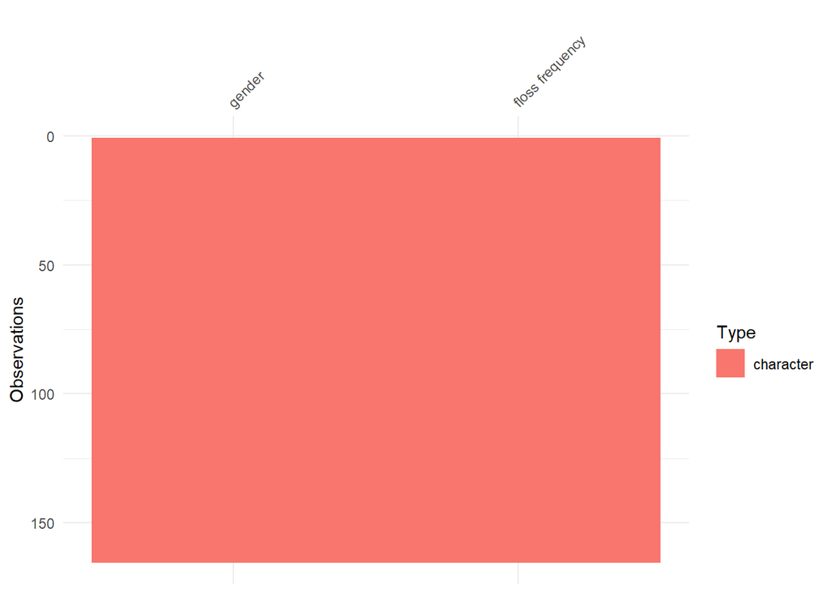

Also, to see if there were some abnormalities, we use `tabyl` to have a look at the distribution. See 5.1. Everything is on the track so that we hide the result here.

```r
tabyl(gender_flossing$gender)
tabyl(gender_flossing$`floss frequency`)
```

### 5.2.2 Change variables into more uniform form.

#### 5.2.2.1 *Gender*

For this column, we have different entries. Now with the help of `toupper(gender)` and `case_when`, we change them into *Female*, *Male*, *Non-binary* as below.

```r
gender_flossing = gender_flossing %>% mutate(
    gender = toupper(gender),
  gender = stringr::str_sub(gender, start = 1, end = 1),
  gender = case_when(
    gender == "F" ~ "Female",
    gender == "M" ~ "Male",
    gender == "N" ~ "Non-binary"
  )
)
```

**Click to have a look**

| gender | floss frequency |
| --- | --- |
| Female | Weekly |
| Male | Less than once a week |
| Male | Less than once a week |
| Male | Every day |
| Male | Every day |
| Male | Less than once a week |
| Male | Every day |
| Male | Less than once a week |
| Female | Less than once a week |
| Male | Less than once a week |
| Female | Less than once a week |
| Male | Weekly |
| Male | Every day |
| Female | Every day |
| Female | Less than once a week |
| Male | Less than once a week |
| Male | Weekly |
| Male | Less than once a week |
| Male | Less than once a week |
| Female | Less than once a week |
| Male | Less than once a week |
| Female | Every day |
| Male | Less than once a week |
| Male | Every day |
| Female | Most days |
| Male | Weekly |
| Female | Most days |
| Male | Weekly |
| Female | Every day |
| Male | Weekly |

[output cut: 135 more lines]

#### 5.2.2.2 *Floss frequency*

As for this column, see Table 5.3 we have already had uniform answers in hand.

```r
janitor::tabyl(gender_flossing$`floss frequency`) %>% `names<-`(c("Floss frequency", "n", "percent")) %>%    knitr::kable(caption = "Floss freqncy column before renaming", align=rep('c', 5),format = "html", table.attr = "style='width:50%;'") %>%
  kableExtra::kable_styling()
```

Table 5.3: Floss freqncy column before renaming

| Floss frequency | n | percent |
| --- | --- | --- |
| Every day | 39 | 0.2363636 |
| Less than once a week | 76 | 0.4606061 |
| Most days | 17 | 0.1030303 |
| Weekly | 33 | 0.2000000 |

But as we have said in 5.2, we have to rearrange them into another concise form. Now the two columns are like below.

```r
gender_flossing = gender_flossing %>% mutate(
  `floss frequency` = toupper(`floss frequency`),
  `floss frequency` = stringr::str_sub(`floss frequency`, start = 1, end = 3),
  `floss frequency`  = case_when(
    `floss frequency`  == "WEE" ~ "At least once a week",
    `floss frequency`  == "EVE" ~ "At least once a week",
    `floss frequency` == "MOS" ~ "At least once a week",
    `floss frequency`  == "LES" ~ "Less than once a week"
  )
)
gender_flossing %>% gt::gt()
```

**Click to have a look**

| gender | floss frequency |
| --- | --- |
| Female | At least once a week |
| Male | Less than once a week |
| Male | Less than once a week |
| Male | At least once a week |
| Male | At least once a week |
| Male | Less than once a week |
| Male | At least once a week |
| Male | Less than once a week |
| Female | Less than once a week |
| Male | Less than once a week |
| Female | Less than once a week |
| Male | At least once a week |
| Male | At least once a week |
| Female | At least once a week |
| Female | Less than once a week |
| Male | Less than once a week |
| Male | At least once a week |
| Male | Less than once a week |
| Male | Less than once a week |
| Female | Less than once a week |
| Male | Less than once a week |
| Female | At least once a week |
| Male | Less than once a week |
| Male | At least once a week |
| Female | At least once a week |
| Male | At least once a week |
| Female | At least once a week |
| Male | At least once a week |
| Female | At least once a week |
| Male | At least once a week |

[output cut: 135 more lines]

### 5.2.3 Testing for independance in 3X2 tables

```r
#Testing for homogeneity in 3X2 tables
tab_gender_flossing = table(gender_flossing)
n_gf = sum(tab_gender_flossing)
r_gf =3
c_gf = 2
row_totals_gf = apply(tab_gender_flossing, 1, sum) # rowSums(tab)
col_totals_gf = apply(tab_gender_flossing, 2, sum) # colSums(tab)
rt_gf = matrix(row_totals_gf, nrow = r_gf,
ncol = c_gf, byrow = FALSE)
ct_gf = matrix(col_totals_gf, nrow = r_gf,
ncol = c_gf, byrow = TRUE)
etab = rt_gf * ct_gf / n_gf
bbb = etab >= 5 # check Eij>=5
bbb %>% as.data.frame() %>% `names<-`(c("At least once a week", "Less than once a week")) %>% `row.names<-`(c("Female","Male","Non-binary")) %>%  knitr::kable(caption = "The expected frequencies", align=rep('c', 5),format = "html", table.attr = "style='width:50%;'") %>%
  kableExtra::kable_styling()
```

Table 5.4: The expected frequencies

|  | At least once a week | Less than once a week |
| --- | --- | --- |
| Female | TRUE | TRUE |
| Male | TRUE | TRUE |
| Non-binary | FALSE | FALSE |

Therefore, we combine the last two classes.The revised table is:

```r
v = tab_gender_flossing %>% matrix(nrow = 3, ncol = 2)
v1=v[1,]
v2 = v[3,]+v[2,]
new_tgf = rbind(v1,v2) %>% as.data.frame() %>%  `names<-`(c("At least once a week", "Less than once a week")) %>% `rownames<-`(c("Female", "Male"))
new_tgf %>% knitr::kable(caption = "The revised table", align=rep('c', 5),format = "html", table.attr = "style='width:50%;'") %>%
  kableExtra::kable_styling()
```

Table 5.5: The revised table

|  | At least once a week | Less than once a week |
| --- | --- | --- |
| Female | 34 | 20 |
| Male | 55 | 56 |

3. **Test statistic**: $T=\sum\limits_{i=1}^2\sum\limits_{j=1}^2\frac{(Y_{ij}-e_{ij})^2}{e_{ij}}$. Under $H_0$, $T \sim \chi_{1}^2$

With new table, using `t0 = sum((new_tgf - new_etab)^2/new_etab)` and `p.value = 1 - pchisq(t0, 1)`, we get $T_0 = 2.630727$, $p-value = 0.1048137$ which are also consistent with the results of built-in function `chisq.test()`.

4. **Observed test statistic**: $t_0=2.630727$
5. **P-value**: $P(T\geq t_0)=P(\chi^2 \geq2.630727)=0.1048137$ Therefore, since the p-value is greater than 0.05, we do not reject the null hypothesis so that there is not sufficiently strong evidence suggesting that floss frequency is related to the gender of DATA2X02 classmates.

```r
new_n_gf = sum(new_tgf)
new_r_gf =2
new_c_gf = 2
new_row_totals_gf = apply(new_tgf, 1, sum) # rowSums(tab)
new_col_totals_gf = apply(new_tgf, 2, sum) # colSums(tab)
new_rt_gf = matrix(new_row_totals_gf, nrow = new_r_gf,
ncol = new_c_gf, byrow = FALSE)
new_ct_gf = matrix(new_col_totals_gf, nrow = new_r_gf,
ncol = new_c_gf, byrow = TRUE)
new_etab = new_rt_gf * new_ct_gf / new_n_gf

t0 = sum((new_tgf - new_etab)^2/new_etab)
p.value = 1 - pchisq(t0, 1)

chisq.test(new_tgf, correct = FALSE)
```

The probability density function is as follows See Figure 5.4.

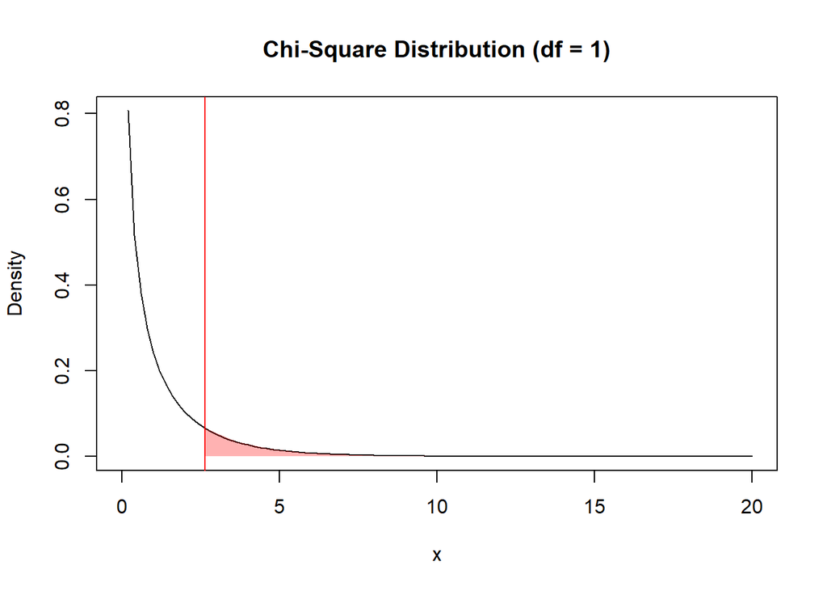

Figure 5.4: Probability density function

```r
#create density curve
curve(dchisq(x, df = 1), from = 0, to = 20,
main = 'Chi-Square Distribution (df = 1)',
ylab = 'Density',
lwd = 1,
)

#create vector of x values
x_vector <- seq(2.630727, 20)

#create vector of chi-square density values
p_vector <- dchisq(x_vector, df = 1)

#fill in portion of the density plot from 0 to 30
polygon(c(x_vector, rev(x_vector)), c(p_vector, rep(0, length(p_vector))),
        col = adjustcolor('red', alpha=0.3), border = NA)
abline(v = 2.630727, col = "red")
```

### 5.2.4 Limitations for the test in this case

```r
x_withoutcpna %>%  filter(university_work == 170) %>% gt::gt()
```

| timestamp | covid_test | gender | postcode | dentist | university_work | social_media | dog_or_cat | live_with_parents | exercising | eye_colour | asthma | paid_work | fav_season | shoe_size | height | floss_frequency | glasses | dominant_hand | steak_preference | stress_level |
| --- | --- | --- | --- | --- | --- | --- | --- | --- | --- | --- | --- | --- | --- | --- | --- | --- | --- | --- | --- | --- |
| 03/09/2020 15:51:05 | 3 | mAle | 2173 | Less than 6 months | 170 | canvas discussion board | No | No | 70 | orange | Yes | 70 | Summer | 9 | 195 | Weekly | No | Ambidextrous | Medium | 6 |

The table above shows all data are filled in by someone who, according to his answer, spent 170 hours per week on university work in semester 1. This is almost impossible. It is easier for us to notice that and also remove them when we are testing something with regard to this sort of data. However, simply examining his ‘stress level’ and ‘gender’, we could not exclude them, which again brings us a new problem ——no one can promise he is treating this survey seriously. We could never avoid the trap this sort of people set for us.

## 5.3 Is the mean stress level of this sample less than 5.1 (on a 10-point scale) that American Psychological Association stated is the average stress level of adults in 2015? (Question5.2-My ‘One Sample test’)

According to a [**Stress Snapshot**](https://www.apa.org/news/press/releases/stress/2015/snapshot) summarized by [**American Psychological Association**](https://www.apa.org/about), based on a 10-level stress choice, adults chose 5.1 as their average rate of stress level. We are going to condut a ‘**One Sample Test**’ to see whether students enrolled in DATA2X02 facing pressure coming from themselves and the uninvited guest, Covid-19, are suffering or not. As what we have done in previous step, see 5.2.1, we will firstly clean our data and exclude the *NA* values

### 5.3.1 Clean *NA* values

Now all *NA* existing in stress level column has been removed from the dataset.

```r
stress_withoutna = x_withoutcpna$stress_level %>% tibble() %>%
  drop_na() %>% c() %>% `names<-`("df_str")
df_str = data.frame(stress_withoutna)
df_str%>%
  gt::gt() %>%
  gt::tab_source_note("Stress level with NA removed")
```

**Click to have a look**

| df_str |
| --- |
| 7 |
| 9 |
| 4 |
| 9 |
| 2 |
| 3 |
| 6 |
| 6 |
| 5 |
| 7 |
| 6 |
| 8 |
| 6 |
| 4 |
| 9 |
| 1 |
| 4 |
| 10 |
| 6 |
| 9 |
| 5 |
| 3 |
| 2 |
| 3 |
| 4 |
| 0 |
| 5 |
| 4 |
| 8 |
| 1 |

[output cut: 140 more lines]

Stress level with NA removed

We could plot a **Box Plot** using `ggplot` and `geom_boxplot` and have a look at the overall distribution of the data. See Figure 5.5

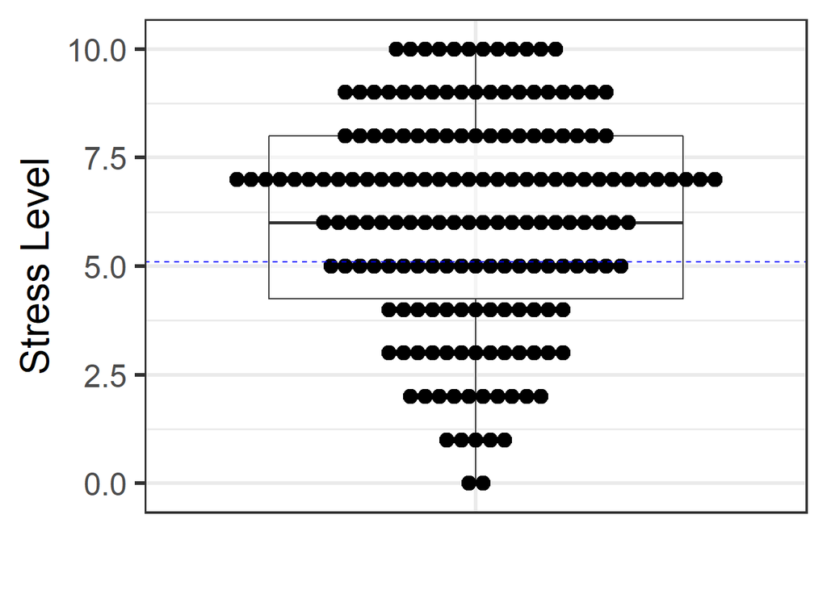

Figure 5.5: The overall distribution of stress level

```r
set.seed(1)
p1_str = ggplot(df_str, aes(x = "", y = df_str)) +
  geom_boxplot(alpha = 0.5, coef = 10) +
  geom_dotplot(binaxis = 'y',stackdir = 'center') +
  geom_hline(yintercept = 5.1,
             colour = "blue",
             linetype = "dashed") +
  labs(y = "Stress Level", x = "") +
  theme_bw(base_size = 24) +
  theme(axis.ticks.x = element_blank(),
        axis.text.x =element_blank())
p1_str
```

### 5.3.2 One sample $t$-test

As we have done with ‘Test for Independence’ (see 5.2.3), some hypothesises and assumptions are required.

1. **Hypothesis**: $\mu=5.1$ vs $H_1:\mu\ne\mu_0$
2. **Assumptions**: $X_i$ are **iid** rv (**Independent and identically distributed random variables**) and follow $N(\mu, \sigma^2)$

Here we obtain the average rate of stress level by `mean()`.

```r
data_str = as.numeric(as.character(unlist(stress_withoutna[[1]])))
average = data_str %>% mean()
average
```

```
## [1] 6.082353
```

3. **Test statistic**: $T = \frac{\bar X - \mu_0}{S/\sqrt{n}}$. Under $H_0$, $T\sim t_{n-1}$.

Thereby, $t_0$ is available which is **5.21652**. Then we could go further in our $t$-test

```r
n=data_str %>% length()
t0 = (mean(data_str) - 5.1)/(sd(data_str)/sqrt(n))
t0
```

```
## [1] 5.21652
```

```r
mean(data_str)
```

```
## [1] 6.082353
```

```r
sd(data_str)
```

```
## [1] 2.455337
```

4. **Observed test statistic**: $t0=\frac{6.082353 - 5.1}{2.455337\sqrt{170}} = 5.21652$
5. **p-value**: $2P(t_{169}\geq |t_0|)$. Because we are conducting the ‘Two-sided t-test’, our p-value then is `(1- pt(t0, n - 1))*2`. Also, this result is consistent with `t.test(data_str, mu = 5.1, alternative = "two.sided")`.

```r
pval = (1- pt(t0, n - 1))*2
pval
```

```
## [1] 5.282965e-07
```

```r
t.test(data_str, mu = 5.1, alternative = "two.sided")
```

Since p-value is too small and, obviously less than $\alpha$ which equals 0.05 in this case, there is sufficiently enough evidence against $H_0$.

6. **Decision**: Therefore, we reject $H_0$ and favor $H_1$, which means that the stress-level of DATA2X02 students’ is not equal to 5.1 on average.

### 5.3.3 Limitations for the test in this case

- For this one sample t-test, we do not have particular requirements for the sample size, but same problem still exists in terms of the reliability of our data in hand. See 5.2.4
- Also, we found a $\mu_0$ which is **5.1** in this case from a report of [**APA**](https://www.apa.org/about) in 2015.
  - Firstly, the average rate of stress level is, more or less, a bit outdated. It is not particularly what we expect for the average rate of DATA2X02 students’ stress level. But fortunately, in this test, we focus much on the overall situation of the stress level. Though 5.1 might not be an average rate we expect, it does not make much difference after all it is around half of ten.
  - Also, during the Covid-19, the overall stress of the public must be surging. Obviously, our $\mu_0$ still does not concern that impact.

## 5.4 Simpsons paradox

AS Tarr mentioned in Lecture02 (2020.a), Simpsons Paradox was first mentioned by British statistician. It means that the association between two certain variables may reverse with entry of a thid variable. Under this category, we would visualize some charts and show the Simpons paradox of our edition if possible.

The first two variables that we choose are respectively gender and stress level. The third variable is the amount of time spent on paid work.

### 5.4.1 Remove *NAs* from our dataset:

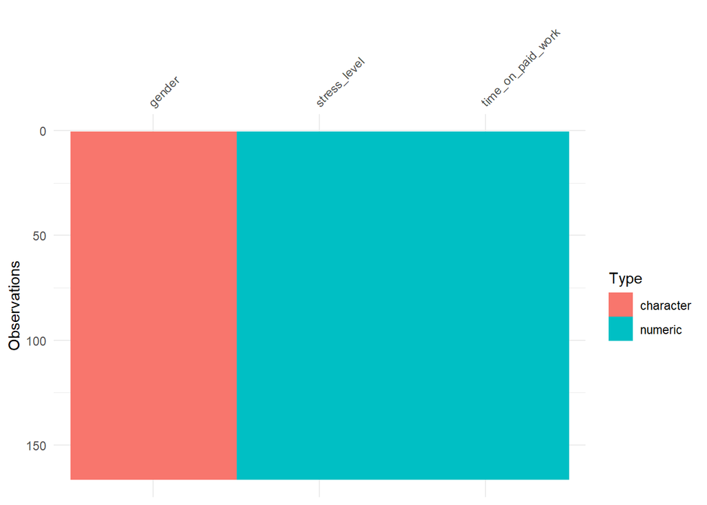

```r
gender_stress = tibble(x_withoutcpna$gender, x_withoutcpna$stress_level, x_withoutcpna$paid_work)
gender_stress = gender_stress %>% drop_na(`x_withoutcpna$gender`)
gender_stress = gender_stress %>% drop_na(`x_withoutcpna$stress_level`)
gender_stress = gender_stress %>% drop_na(`x_withoutcpna$paid_work`)
gender_stress = gender_stress %>% as.data.frame() %>% `names<-`(c("gender", "stress_level ", "time_on_paid_work"))
visdat::vis_dat(gender_stress)
```

### 5.4.2 Remove abnormal value.

#### 5.4.2.1 Visualize the *gender* column

```r
tabyl(gender_stress$`gender`) %>% gt::gt()
```

**Click to have a look**

| gender_stress$gender | n | percent |
| --- | --- | --- |
| F | 6 | 0.036144578 |
| femail | 1 | 0.006024096 |
| female | 7 | 0.042168675 |
| Female | 39 | 0.234939759 |
| FEMALE | 1 | 0.006024096 |
| m | 2 | 0.012048193 |
| M | 5 | 0.030120482 |
| male | 18 | 0.108433735 |
| mAle | 1 | 0.006024096 |
| Male | 82 | 0.493975904 |
| MALE | 1 | 0.006024096 |
| Non-binary | 1 | 0.006024096 |
| Non-Binary | 1 | 0.006024096 |
| non binary | 1 | 0.006024096 |

#### 5.4.2.2 Visualize the *stress level* column

```r
tabyl(gender_stress$`stress_level `) %>% gt::gt()
```

**Click to have a look**

| gender_stress$`stress_level ` | n | percent |
| --- | --- | --- |
| 0 | 2 | 0.01204819 |
| 1 | 5 | 0.03012048 |
| 2 | 10 | 0.06024096 |
| 3 | 13 | 0.07831325 |
| 4 | 13 | 0.07831325 |
| 5 | 20 | 0.12048193 |
| 6 | 21 | 0.12650602 |
| 7 | 33 | 0.19879518 |
| 8 | 18 | 0.10843373 |
| 9 | 19 | 0.11445783 |
| 10 | 12 | 0.07228916 |

The first two columns are all seemingly normal other than the third one where we have someone spending **70** and **75 hours per week** on paid work, which seems impossible. Therefore, we would remove these two rows.

#### 5.4.2.3 Visualize the *time on paid work* column

```r
tabyl(gender_stress$`time_on_paid_work`) %>% gt::gt()
```

**Click to have a look**

| gender_stress$time_on_paid_work | n | percent |
| --- | --- | --- |
| 0 | 75 | 0.451807229 |
| 1 | 4 | 0.024096386 |
| 2 | 8 | 0.048192771 |
| 3 | 8 | 0.048192771 |
| 4 | 4 | 0.024096386 |
| 5 | 4 | 0.024096386 |
| 6 | 3 | 0.018072289 |
| 7 | 4 | 0.024096386 |
| 8 | 7 | 0.042168675 |
| 9 | 1 | 0.006024096 |
| 10 | 14 | 0.084337349 |
| 12 | 4 | 0.024096386 |
| 14 | 1 | 0.006024096 |
| 15 | 6 | 0.036144578 |
| 16 | 2 | 0.012048193 |
| 18 | 1 | 0.006024096 |
| 20 | 9 | 0.054216867 |
| 21 | 1 | 0.006024096 |
| 24 | 1 | 0.006024096 |
| 25 | 3 | 0.018072289 |
| 28 | 1 | 0.006024096 |
| 30 | 1 | 0.006024096 |
| 35 | 1 | 0.006024096 |
| 48 | 1 | 0.006024096 |
| 70 | 1 | 0.006024096 |
| 75 | 1 | 0.006024096 |

Therefore, we have data as below in hand (Notice that we have changed the value under gender column as what we have done before See 5.2.2.1 ).

```r
gender_stress = filter(gender_stress, time_on_paid_work != 70)
gender_stress = filter(gender_stress, time_on_paid_work != 75)

gender_stress = gender_stress %>% mutate(
    gender = toupper(gender),
  gender = stringr::str_sub(gender, start = 1, end = 1),
  gender = case_when(
    gender == "F" ~ "Female",
    gender == "M" ~ "Male",
    gender == "N" ~ "Non-binary"
  )
)

gender_stress %>% gt::gt()
```

**Click to have a look**

| gender | stress_level | time_on_paid_work |
| --- | --- | --- |
| Female | 7 | 0 |
| Male | 9 | 0 |
| Male | 4 | 2 |
| Male | 9 | 0 |
| Male | 2 | 8 |
| Male | 3 | 10 |
| Male | 6 | 10 |
| Female | 5 | 10 |
| Male | 7 | 10 |
| Female | 6 | 0 |
| Male | 8 | 12 |
| Male | 6 | 0 |
| Female | 4 | 0 |
| Female | 9 | 0 |
| Male | 1 | 0 |
| Male | 4 | 0 |
| Male | 10 | 48 |
| Male | 6 | 18 |
| Female | 9 | 10 |
| Male | 5 | 10 |
| Female | 3 | 5 |
| Male | 2 | 0 |
| Male | 3 | 0 |
| Female | 4 | 0 |
| Male | 0 | 3 |
| Female | 5 | 5 |
| Male | 4 | 0 |
| Female | 8 | 0 |
| Male | 1 | 0 |
| Female | 7 | 0 |

[output cut: 134 more lines]

We have to redesign the hierarchy of *Stress level* column in order to visualize the overall state of our sample. See below our new classification

| Stress underload | Optimum stress | Stress overload |
| --- | --- | --- |
| 0-3 | 4-7 | 8-10 |

```r
tabyl(gender_stress$`time_on_paid_work`) %>% gt::gt()
```

**Click to have a look**

```
##  gender_stress$time_on_paid_work  n     percent
##                                0 75 0.457317073
##                                1  4 0.024390244
##                                2  8 0.048780488
##                                3  8 0.048780488
##                                4  4 0.024390244
##                                5  4 0.024390244
##                                6  3 0.018292683
##                                7  4 0.024390244
##                                8  7 0.042682927
##                                9  1 0.006097561
##                               10 14 0.085365854
##                               12  4 0.024390244
##                               14  1 0.006097561
##                               15  6 0.036585366
##                               16  2 0.012195122
##                               18  1 0.006097561
##                               20  9 0.054878049
##                               21  1 0.006097561
##                               24  1 0.006097561
##                               25  3 0.018292683
##                               28  1 0.006097561
##                               30  1 0.006097561
##                               35  1 0.006097561
##                               48  1 0.006097561
```

#### 5.4.2.4 Redesign the *Stress level*

```r
gender_stress = gender_stress %>%  mutate(
  `stress_level ` = case_when(
  `stress_level `== 0 ~ "Stress underload",
 `stress_level `== 1 ~ "Stress underload",
  `stress_level `== 2 ~ "Stress underload",
  `stress_level `== 3 ~ "Stress underload",
  `stress_level `== 4 ~ "Optimum stress",
  `stress_level `== 5 ~ "Optimum stress",
  `stress_level `== 6 ~ "Optimum stress",
  `stress_level `== 7 ~ "Optimum stress",
  `stress_level `== 8 ~ "Stress overload",
  `stress_level `== 9 ~ "Stress overload",
  `stress_level `== 10 ~ "Stress overload"

  )

)
gender_stress %>% gt::gt()
```

**Click to have a look**

| gender | stress_level | time_on_paid_work |
| --- | --- | --- |
| Female | Optimum stress | 0 |
| Male | Stress overload | 0 |
| Male | Optimum stress | 2 |
| Male | Stress overload | 0 |
| Male | Stress underload | 8 |
| Male | Stress underload | 10 |
| Male | Optimum stress | 10 |
| Female | Optimum stress | 10 |
| Male | Optimum stress | 10 |
| Female | Optimum stress | 0 |
| Male | Stress overload | 12 |
| Male | Optimum stress | 0 |
| Female | Optimum stress | 0 |
| Female | Stress overload | 0 |
| Male | Stress underload | 0 |
| Male | Optimum stress | 0 |
| Male | Stress overload | 48 |
| Male | Optimum stress | 18 |
| Female | Stress overload | 10 |
| Male | Optimum stress | 10 |
| Female | Stress underload | 5 |
| Male | Stress underload | 0 |
| Male | Stress underload | 0 |
| Female | Optimum stress | 0 |
| Male | Stress underload | 3 |
| Female | Optimum stress | 5 |
| Male | Optimum stress | 0 |
| Female | Stress overload | 0 |
| Male | Stress underload | 0 |
| Female | Optimum stress | 0 |

[output cut: 134 more lines]

### 5.4.3 Visualize the dataset

Now we will visualize the association between gender and stress level by `ggplot()`. (See Figure 5.6)

We could find that with males’ proportion of *Stress overload* being less than that of females’ (We have a poor amount of data from *Non-binary* so that this bar might not be representative enough), we could deduce that probably females are facing huge stress.

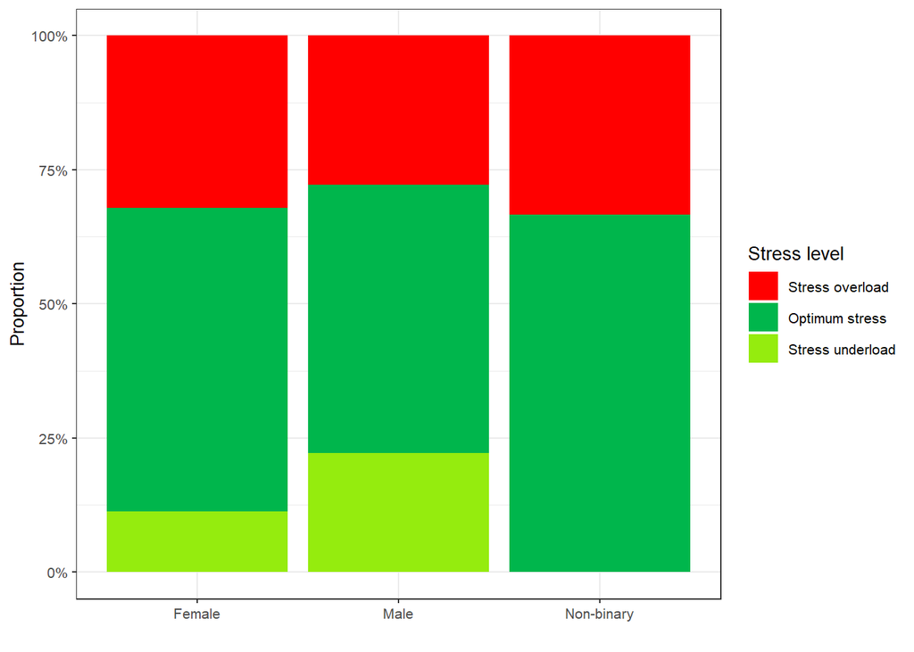

Figure 5.6: First stage of proving Simpsons paradox

```r
tab_g_s_wp = table(gender_stress$gender, gender_stress$`stress_level`) %>% data.frame() %>% `names<-`(c("gender", "Stress", "Frequency"))
#rm(tab_g_s_wp)
ggplot(tab_g_s_wp,
       aes(x = tab_g_s_wp$gender, y = tab_g_s_wp$Frequency, fill = factor(tab_g_s_wp$Stress, levels = c('Stress overload', 'Optimum stress', 'Stress underload')))) +
  geom_bar(stat = "identity", position="fill") +
  scale_y_continuous(labels = scales::percent_format()) +
  labs(x = "", y = "Proportion") +
  theme_bw(base_size = 10) +
  scale_fill_brewer(palette = "Set1")+
  scale_fill_manual(name= 'Stress level',
                    values = c('Red', '#00B64C', '#95EC0E'))
```

Then we introduce the third variable which is *paid work* column. To begin with, we have to assign different values to differnt group like what we have done previously. See 5.4.2.4.

```r
gender_stress = gender_stress %>%  mutate(
    `time_on_paid_work` = case_when(
    gender_stress$`time_on_paid_work` <= 2 & gender_stress$time_on_paid_work >=0 ~ "0-2",
    gender_stress$time_on_paid_work <= 6 & gender_stress$time_on_paid_work >=3 ~ "3-6",
    gender_stress$time_on_paid_work <= 10 & gender_stress$time_on_paid_work >=7 ~ "7-10",
    gender_stress$time_on_paid_work <= 14 & gender_stress$time_on_paid_work >=11 ~ "11-14",
    gender_stress$time_on_paid_work <= 18 & gender_stress$time_on_paid_work >=15 ~ "15-18",
    gender_stress$time_on_paid_work <= 22 & gender_stress$time_on_paid_work >=19 ~ "19-22",
    gender_stress$time_on_paid_work <= 25 & gender_stress$time_on_paid_work >=23 ~ "23-25",
    gender_stress$time_on_paid_work >= 26  ~ "26+"
    ))
gender_stress %>% gt::gt()
```

**Click to have a look**

| gender | stress_level | time_on_paid_work |
| --- | --- | --- |
| Female | Optimum stress | 0-2 |
| Male | Stress overload | 0-2 |
| Male | Optimum stress | 0-2 |
| Male | Stress overload | 0-2 |
| Male | Stress underload | 7-10 |
| Male | Stress underload | 7-10 |
| Male | Optimum stress | 7-10 |
| Female | Optimum stress | 7-10 |
| Male | Optimum stress | 7-10 |
| Female | Optimum stress | 0-2 |
| Male | Stress overload | 11-14 |
| Male | Optimum stress | 0-2 |
| Female | Optimum stress | 0-2 |
| Female | Stress overload | 0-2 |
| Male | Stress underload | 0-2 |
| Male | Optimum stress | 0-2 |
| Male | Stress overload | 26+ |
| Male | Optimum stress | 15-18 |
| Female | Stress overload | 7-10 |
| Male | Optimum stress | 7-10 |
| Female | Stress underload | 3-6 |
| Male | Stress underload | 0-2 |
| Male | Stress underload | 0-2 |
| Female | Optimum stress | 0-2 |
| Male | Stress underload | 3-6 |
| Female | Optimum stress | 3-6 |
| Male | Optimum stress | 0-2 |
| Female | Stress overload | 0-2 |
| Male | Stress underload | 0-2 |
| Female | Optimum stress | 0-2 |

[output cut: 134 more lines]

We extract data about people feeling **Stress overload** from the dataset and calculate its proportion. Thereby, we have three columns which are exactly our basis for the proof og Simpsons paradox as below.

```r
tibble_w_g_p = tibble(gender_stress$time_on_paid_work, gender_stress$gender, gender_stress$`stress_level `)


data_w_g_spwlevel = c("0-2", "3-6", "7-10",
                 "11-14", "15-18", "19-22", "23-25", "26+")
tibble_w_g_p = tibble_w_g_p %>%
  mutate(
    `gender_stress$time_on_paid_work` = factor(tibble_w_g_p$`gender_stress$time_on_paid_work`, levels = data_w_g_spwlevel)
  ) %>% `names<-`(c("paid_work","gender","stress_level"))
tab_wgsp = table(tibble_w_g_p$paid_work,  tibble_w_g_p$stress_level,tibble_w_g_p$gender)
ww = ftable(tab_wgsp,row.vars =1,col.vars = 2:3)
ww
qe = data.frame(ww)
names(qe)=c("workgroup", "stresslevel", "gender", "count")
qel = qe %>%
  tidyr::pivot_wider(id_cols = workgroup,
  names_from = c(stresslevel, gender),
  values_from = count,
  names_sep = " ")
percent = qe %>%
  uncount(weights = count) %>%
  group_by(gender, workgroup) %>%
  summarise(rate_stressoverload = mean(stresslevel=="Stress overload"))
```

**Click to have a look**

```
##        Optimum stress                 Stress overload                 Stress underload
##                Female Male Non-binary          Female Male Non-binary           Female Male Non-binary
##
## 0-2                15   34          1              10   15          0                2   10          0
## 3-6                 3    3          0               2    2          1                1    7          0
## 7-10                5   11          0               2    3          0                1    4          0
## 11-14               1    0          0               1    2          0                1    0          0
## 15-18               3    4          0               0    2          0                0    0          0
## 19-22               2    2          0               1    3          0                1    1          0
## 23-25               0    0          1               0    1          0                0    2          0
## 26+                 1    0          0               1    2          0                0    0          0
```

Then we grouped them by **paid work** and see what is the proportion of different genders feeling stress overload in each group.See Figure 5.7.

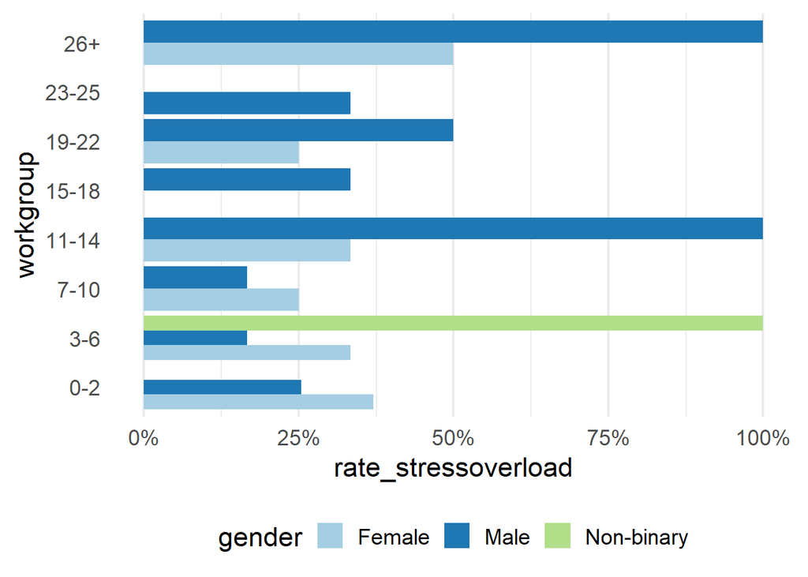

```r
chart = percent %>%
  ggplot() +
  aes(x = workgroup, y = rate_stressoverload, fill = gender) +
  geom_bar(stat = "identity", position = "dodge") +
  theme_minimal(base_size = 17) +
  scale_fill_brewer(palette = "Paired") +
  scale_y_continuous(labels = scales::percent_format())+
  theme(panel.grid.major.y = element_blank(), legend.position = "bottom") +
  coord_flip()
chart
```

# 6 References

American Psychological Association. (2015). *2015 Stress in America™*. https://www.apa.org/news/press/releases/stress/2015/snapshot

Elfil, M., & Negida, A. (2017). Sampling methods in clinical research; an educational review. *Emergency*, 5(1).

Tarr, G.(2020.a).*Collecting data* [PowerPoint slide]. Lecture02. Retrieved from https://pages.github.sydney.edu.au/DATA2002/2020/lectures/lec02.html#1

Beaudry, Jennifer, Emily Kothe, Felix Singleton Thorn, and Rhydwyn McGuire. 2020. *GendercodeR: Recodes Sex/Gender Descriptions into a Standard Set*. https://github.com/ropenscilabs/gendercoder.

Dowle, Matt, and Arun Srinivasan. 2020. *Data.table: Extension of ‘Data.frame‘*. https://CRAN.R-project.org/package=data.table.

Firke, Sam. 2020. *Janitor: Simple Tools for Examining and Cleaning Dirty Data*. https://CRAN.R-project.org/package=janitor.

Tierney, Nicholas. 2017. “Visdat: Visualising Whole Data Frames.” *JOSS* 2 (16): 355. https://doi.org/10.21105/joss.00355.

———. 2019. *Visdat: Preliminary Visualisation of Data*. https://CRAN.R-project.org/package=visdat.

Waring, Elin, Michael Quinn, Amelia McNamara, Eduardo Arino de la Rubia, Hao Zhu, and Shannon Ellis. 2020. *Skimr: Compact and Flexible Summaries of Data*. https://CRAN.R-project.org/package=skimr.

Wickham, Hadley. 2016. *Ggplot2: Elegant Graphics for Data Analysis*. Springer-Verlag New York. https://ggplot2.tidyverse.org.

Wickham, Hadley, Mara Averick, Jennifer Bryan, Winston Chang, Lucy D’Agostino McGowan, Romain François, Garrett Grolemund, et al. 2019. “Welcome to the tidyverse.” *Journal of Open Source Software* 4 (43): 1686. https://doi.org/10.21105/joss.01686.

Wickham, Hadley, Winston Chang, Lionel Henry, Thomas Lin Pedersen, Kohske Takahashi, Claus Wilke, Kara Woo, Hiroaki Yutani, and Dewey Dunnington. 2020. *Ggplot2: Create Elegant Data Visualisations Using the Grammar of Graphics*. https://CRAN.R-project.org/package=ggplot2.

Wickham, Hadley, Romain Fran?ois, Lionel Henry, and Kirill Müller. 2020. *Dplyr: A Grammar of Data Manipulation*. https://CRAN.R-project.org/package=dplyr.

Xie, Yihui. 2016. *Bookdown: Authoring Books and Technical Documents with R Markdown*. Boca Raton, Florida: Chapman; Hall/CRC. https://github.com/rstudio/bookdown.

———. 2020. *Bookdown: Authoring Books and Technical Documents with R Markdown*. https://CRAN.R-project.org/package=bookdown.

Zhu, Hao. 2020. *KableExtra: Construct Complex Table with ’Kable’ and Pipe Syntax*. https://CRAN.R-project.org/package=kableExtra.